# Lab 3 Revision

- Show All Code
- Hide All Code
- View Source

Author

Jasmine Cabrera

The downloaded file **does not** contain an YAML, you need to include your own. This allows you to specify how you would like your rendered HTML to look! The sky is the limit! :::

Download `hiphop.csv`

**Warning**

Save **both** your .qmd file and your data set in the same folder within your Stat 331 directory! **DO NOT** open your .qmd file straight from your downloads folder.

## Tips for Formatting your Lab

**Tip**

- The first chunk of your Quarto document should be to *declare your libraries* (probably only `tidyverse` for now).
- The second chunk of your Quarto document should be to *load in your data* (using the `here()` function!).
- Make sure you address **all the questions** in these instructions.
- If a question requires **any** type of calculation, **you should provide code for your answer!**
- I have provided hints about functions that might be useful to you. You are **not required** to use these functions.
- You may have to Google to solve some of these!
- Be sure to **save** your work regularly (`Ctrl/Cmd + S` or `File > Save` or the floppy disk icon)
- Be sure to **render** your file every so often, to check for errors and make sure it looks nice.
  - Make your Quarto document does not contain `View(dataset)` or `install.packages("package")`, both of these will prevent rendering.
  - Check your Quarto document for moments when you looked at the data by typing the name of the data frame. Leaving these in means the whole dataset will print out and this looks unprofessional.
  - If you are unable to finish due to errors in your code, remember that you can still submit an HTML file if you specify `error: true` in your `execute` options (in the YAML).

# Data Set

The data set `hiphop` contains results from a study conducted by a linguist at the University of Minnesota. The researcher was interested in predicting musical taste based on familiarity with African American English (AAE). 168 subjects participated in the study, and each was asked to define 64 different AAE terms. The definitions given were used to create a `familiarity` score for each subject for each term. This score quantifies how well the subject knew the term on a scale of 1-5 (1 = not at all, 5 = very well). Before tackling the problems, study the description of each variable [here](http://conservancy.umn.edu/bitstream/handle/11299/116327/5/explanationAAEHiphopChesley.txt).

**1. Load the appropriate R packages and import the data set, `hiphop`.**

```r
# code chunk for loading packages and importing the data
#| message: false

# Loads in packages
library(tidyverse)
library(here)

# Imports data
hiphop <- read_csv(here("hiphop.csv"))
```

Q1 Fix - Considered S: Fixed error message by specifying error: false in YAML.

## Summary

**2. Provide a brief overview (2-4 sentences) of the data set.**

```r
# you may want to use code to answer this question

# Outputs dimensions of data set
dim(hiphop)
```

```
[1] 10752    38
```

```r
# Outputs data types of data set
str(hiphop)
```

```
spc_tbl_ [10,752 × 38] (S3: spec_tbl_df/tbl_df/tbl/data.frame)
 $ word               : chr [1:10752] "[to be] ghost" "[to be] ghost" "[to be] ghost" "[to be] ghost" ...
 $ subj               : chr [1:10752] "p15" "p53" "p136" "p36" ...
 $ sex                : chr [1:10752] "Female" "Female" "Male" "Female" ...
 $ age                : num [1:10752] 20 17 41 18 18 19 18 18 19 19 ...
 $ ethnic             : chr [1:10752] "white" "white" "white" "white" ...
 $ city               : num [1:10752] 33283 34033 8789 712 24280 ...
 $ county             : num [1:10752] 1156212 396500 58696 148955 153504 ...
 $ intl               : num [1:10752] 0 0 0 0 0 0 0 0 0 0 ...
 $ vocal              : num [1:10752] 0 0 2 0 3 0 0 0 0 1 ...
 $ classical          : num [1:10752] 0 0 0 0 3 0 0 0 0 0 ...
 $ folk               : num [1:10752] 0 0 0 1 0 0 2 0 0 0 ...
 $ rock               : num [1:10752] 1 0 0 1 1 0 0 1 0 4 ...
 $ country            : num [1:10752] 3 1 0 2 0 1 0 3 0 4 ...
 $ pop                : num [1:10752] 4 3 0 2 3 1 0 1 0 4 ...
 $ alternative        : num [1:10752] 1 0 0 3 1 0 3 1 0 4 ...
 $ hiphop             : num [1:10752] 7 3 0 3 0 3 0 4 5 0 ...
 $ unclassifiable     : num [1:10752] 0 0 0 0 0 0 0 0 0 0 ...
 $ countyBlack        : num [1:10752] 126221 18064 413 24 6115 ...
 $ jayz               : num [1:10752] 5 5 1 5 1 5 5 5 5 1 ...
 $ barkley            : num [1:10752] 5 1 1 3 1 5 1 2 5 1 ...
 $ boondocks          : num [1:10752] 1 1 1 1 1 1 1 5 5 1 ...
 $ monique            : num [1:10752] 4 3 1 1 1 1 3 1 3 1 ...
 $ bieber             : num [1:10752] 6 6 1 4 2 3 2.5 1 2 2 ...
 $ asianMove          : num [1:10752] 3 0 0 1 0.75 0 0 0 5 1 ...
 $ blackMove          : num [1:10752] 3 0 0 0 0.592 ...
 $ hispanicMove       : num [1:10752] 2 1 0 0 0.353 ...
 $ nativeMove         : num [1:10752] 0 0 0 0 0.0318 ...
 $ SAAMEMove          : num [1:10752] 0 0 0 0 0.295 ...
 $ whiteMove          : num [1:10752] 9 1 2 9 6.29 ...
 $ blackWeekly        : num [1:10752] 3 0 0 1 5 3 2 7 6 1 ...
 $ jayz1              : num [1:10752] 1 1 0 1 0 1 1 1 1 0 ...
 $ boondocks1         : num [1:10752] 0 0 0 0 0 0 0 1 1 0 ...
 $ familiarity        : num [1:10752] 1 1 1 1 1 1 1 1 5 1 ...
 $ trial              : num [1:10752] 26 14 3 12 53 23 25 16 2 29 ...
 $ fam1               : num [1:10752] 0 0 0 0 0 0 0 0 1 0 ...
 $ popularityScore    : num [1:10752] 33 33 33 33 33 33 33 33 33 33 ...
 $ numPreferredArtists: num [1:10752] 1 1 NA 0 NA 0 NA 1 0 NA ...
 $ numOverallArtists  : num [1:10752] 7 7 NA 7 NA 7 NA 7 7 NA ...
 - attr(*, "spec")=
```

[output cut: 26 more lines]

```
  ..   hispanicMove = col_double(),
  ..   nativeMove = col_double(),
  ..   SAAMEMove = col_double(),
  ..   whiteMove = col_double(),
  ..   blackWeekly = col_double(),
  ..   jayz1 = col_double(),
  ..   boondocks1 = col_double(),
  ..   familiarity = col_double(),
  ..   trial = col_double(),
  ..   fam1 = col_double(),
  ..   popularityScore = col_double(),
  ..   numPreferredArtists = col_double(),
  ..   numOverallArtists = col_double()
  .. )
 - attr(*, "problems")=<externalptr>
```

Q2 Answer: From the output “10752 38”, we know that the hip hop data set has 10,752 rows and 38 columns. Out of the 38 variables, there are 4 character variables and 34 numeric variables.

Q2 Fix: Placing Answers to questions in report section and not in comment section.

**3. What are the rows of this data set?**

```r
# you may want to use code to answer this question

# https://conservancy.umn.edu/bitstream/handle/11299/116327/5/explanationAAEHiphopChesley.txt
# Gets frequency of each "word"
hiphop |>
  count(word)
```

```
# A tibble: 64 × 2
   word              n
   <chr>         <int>
 1 [to be] ghost   168
 2 5-0             168
 3 A-town          168
 4 ashy            168
 5 ay yo trip      168
 6 ballin'         168
 7 beezy           168
 8 bones           168
 9 boo             168
10 boughie         168
# … with 54 more rows
```

Q3 Answer: After reading the description provided by the researcher, I believe that each row is designed to represent one word being tested. The code supports this theory since there are 168 participants and 64 words as stated in the document. Therefore, the count function should create a 64 x 2 tibble containing 64 words each with a frequency of 168 (one for each participant).

Q3 Fix: Placing Answers to questions in report section and not in comment section.

## Cleaning the Data

**4. Missing values for some of the variables were replaced with other values. How were missing values replaced? What do you believe are some benefits and drawbacks of doing this?**

```r
# you may want to use code to answer this question

# https://conservancy.umn.edu/bitstream/handle/11299/116327/5/explanationAAEHiphopChesley.txt
```

Q4 Answer: As stated in the research document, the missing values were replaced with mean values in the social network variables (i.e. blackWeekly). The benefits of doing so are that the data would no longer have NA values and calculations can easily be computed without the worry of receiving an error. The drawbacks, however, are that these mean values are not from the raw data, and thus, these values can skew and change the results of computation.

Q4 Fix: Placing Answers to questions in report section and not in comment section.

**5. Clean the data set in whichever ways you see fit. This might mean adjusting *variable type*, for example from `character` to `factor`, or dealing with missing data. Assign your cleaned data set to a new data set named `hiphop_clean` – use this data set going forward.**

```r
# code chunk for Q5
# Creates new data set "hiphop_clean" using certain variables from data set "hiphop"
hiphop_clean <- hiphop |>
  select(
    word, subj, sex, age, ethnic, familiarity, trial, fam1, popularityScore,
    city, county, bieber) |>

# Variable "familiarity" is converted to factor
  mutate(
    familarity = as.factor(familiarity))
```

# Data Summaries

**6. How many unique AAE words were studied in this data set?**

```r
# code chunk for Q6
# Displays each unique word
hiphop_clean |>
  distinct(word)
```

```
# A tibble: 64 × 1
   word
   <chr>
 1 [to be] ghost
 2 5-0
 3 A-town
 4 ashy
 5 ay yo trip
 6 ballin'
 7 beezy
 8 bones
 9 boo
10 boughie
# … with 54 more rows
```

Q6 Answer: There are 64 unique AAE words studied in this data set. This is shown in the 64x1 tibble output that displays each unique word.

Q6 Fix: Used the distinct function which created a tibble of each unique word instead of relying on the count function.

**7. Make a new variable that re-categorizes `ethnic` into only two groups, “white” and “non-white”, to simplify your data.**

**Tip**

Helpful functions: `mutate()`, `if_else()`

```r
# code chunk for Q7
# Creates new variable "ethnic_bin" that re-categorizes variable "ethnic" into
# two groups (white and non-white)
hiphop_clean <- hiphop_clean |>
  mutate(ethnic_bin =
           case_when(ethnic == "white" ~ "white",
                           TRUE ~ "non-white"))
```

Q7 Fix: Made it so that hiphop_clean created and saved a variable in its own data set rather than just creating one.

**8. It is fairly common for researchers to collapse ethnic or racial categories similar to what you just did. What are some issues with representing the data in this way?**

One issues with collapsing ethnic or racial categories is that it generalizes all other minorities into one category. This can be very misleading for data analysis because you don’t know which minorities are under or over represented.

**9. What are the demographics of the people in this study? Investigate the variables `sex`, `age`, and `ethnic` and summarize your findings in 1-3 complete sentences.**

In regards to sex, there are 117 females and 51 males in this study. Their ages span from 16 to 48 years old with a mean of 20.02 years old. There are 5 of African descent, 19 of Asian descent, 1 of Biracial descent, 1 of Black descent, 3 of Hispanic descent, 2 of Indian descent, 1 of Native descent, 1 of unknown descent and 135 of White descent.

**Tip**

You’ll need to first manipulate your data to have each person represented only once.

Helpful functions: `select()`, `distinct(___, .keep_all = TRUE)`, `count()`, `summary()`

```r
# code chunk for Q9
# Creates new data set "new_hiphop" from data set "hiphop_clean" to have each
# person represented only once
new_hiphop <- hiphop_clean |>
  select(subj, sex, age, ethnic) |>
  distinct(subj, .keep_all = TRUE)

# Finds frequency of males and females
new_hiphop |>
  count(sex)
```

```
# A tibble: 2 × 2
  sex        n
  <chr>  <int>
1 Female   117
2 Male      51
```

```r
# Finds frequency of each ethnic group
new_hiphop |>
  count(ethnic)
```

```
# A tibble: 9 × 2
  ethnic       n
  <chr>    <int>
1 african      5
2 asian       19
3 biracial     1
4 black        1
5 hispanic     3
6 indian       2
7 native       1
8 unknown      1
9 white      135
```

```r
# Calculates 5 number summary for age
new_hiphop |>
  summarize(age)
```

```
# A tibble: 168 × 1
     age
   <dbl>
 1    20
 2    17
 3    41
 4    18
 5    18
 6    19
 7    18
 8    18
 9    19
10    19
# … with 158 more rows
```

Q9 Fix - Considered S: Uses summarize function as suggested instead of summary function.

**10. Make at least two plots to display the demographic information of the subjects in this study.**

**Note**

You do not need to discuss these plots, but make sure they are appropriate to the data types and have informative titles and axis labels. Feel free to use the skills you learned in Challenge 2 to enhance your plots!

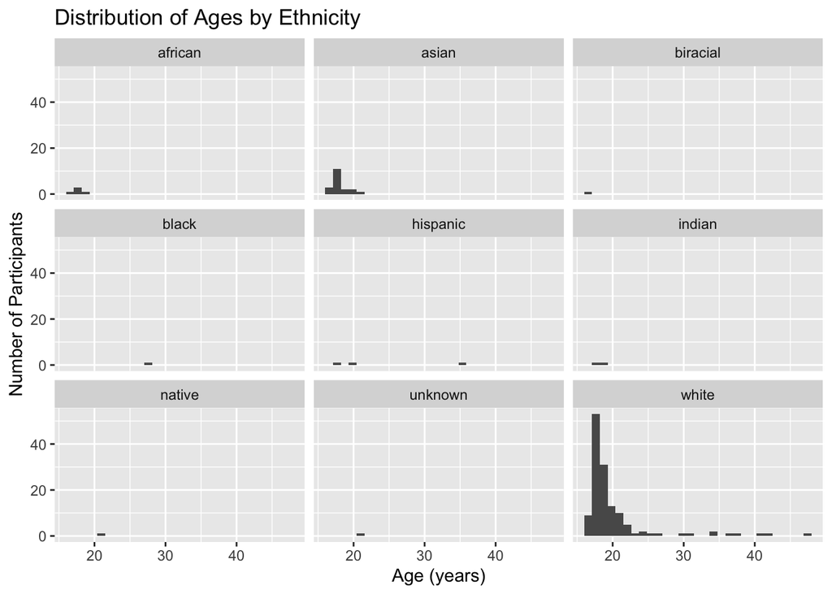

```r
# code chunk for Q10
# Plot 1
ggplot(data = new_hiphop,
       mapping = aes(x = age)) +
  geom_histogram() +
  facet_wrap(~ ethnic) +
  labs(title = "Distribution of Ages by Ethnicity",
       x = "Age (years)",
       y = "Number of Participants")
```

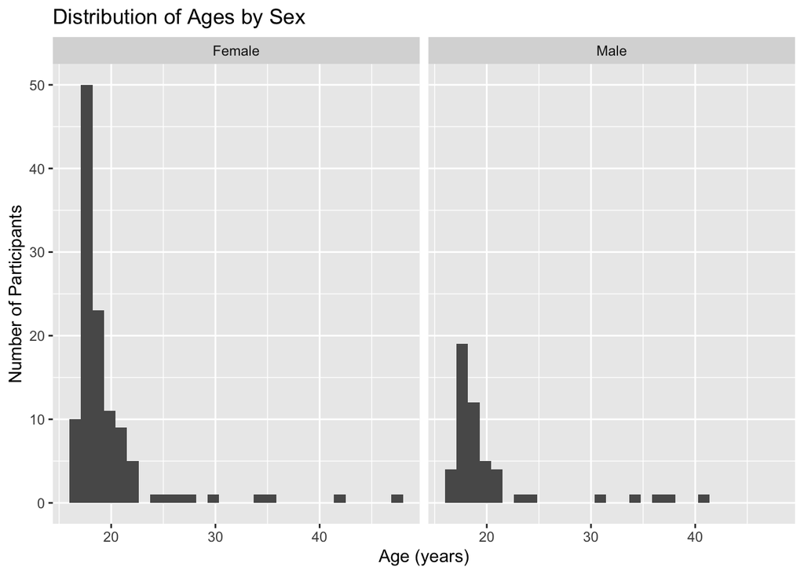

```r
# Plot 2
ggplot(data = new_hiphop,
       mapping = aes(x = age)) +
  geom_histogram() +
  facet_wrap(~ sex) +
  labs(title = "Distribution of Ages by Sex",
       x = "Age (years)",
       y = "Number of Participants")
```

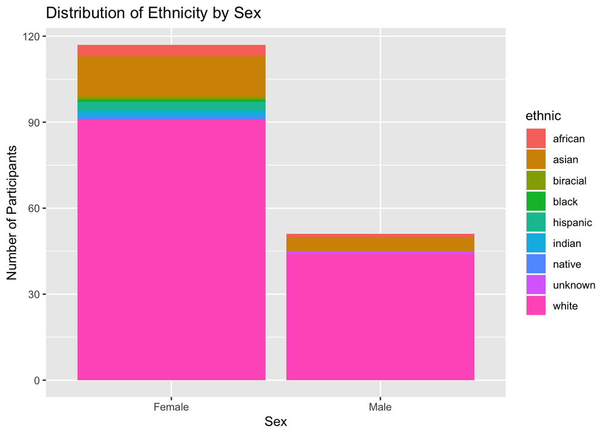

```r
# Plot 3
ggplot(data = new_hiphop,
       mapping = aes(x = sex,
                     fill = ethnic)) +
  geom_bar() +
  labs(title = "Distribution of Ethnicity by Sex",
       x = "Sex",
       y = "Number of Participants")
```

## Familiar words

For each demographic group listed below, determine which word(s) in this study was(were) the most **and** least familiar on average.

**Tip**

Helpful functions: `filter()`, `group_by()`, `summarize()`, `slice_max()`, `slice_min()`

Useful variables: `word`, `familiarity`, `sex`, `age`, `ethnic`

**11. People below the age of 20.**

```r
# code chunk for Q11
# Determines which word was the most familiar
hiphop_clean |>
  filter(age < 20,
         familiarity == 5) |>
  count(word, sort = TRUE)
```

```
# A tibble: 59 × 2
   word             n
   <chr>        <int>
 1 off the hook    93
 2 feel me         91
 3 hella           71
 4 boo             64
 5 what it do      56
 6 finna           44
 7 ashy            43
 8 chedda          41
 9 5-0             40
10 make it rain    38
# … with 49 more rows
```

```r
# Determines which words was the least familiar
hiphop_clean |>
  filter(age < 20,
         familiarity == 1) |>
  count(word, sort = TRUE)
```

```
# A tibble: 64 × 2
   word                  n
   <chr>             <int>
 1 catch the vapors    117
 2 domino              116
 3 face gator          115
 4 rollie              115
 5 break someone out   114
 6 dukey rope          114
 7 grip grain          114
 8 humming             114
 9 saditty             114
10 plex                113
# … with 54 more rows
```

Q11 Answer: For people below the age of 20, the word that was most familiar was “off the hook” which 93 people marked with a familiarity of 5. The word that was the least familiar was “catch the vapors” which had 117 people mark it with a familiarity of 1.

**12. Non-white women.**

```r
# code chunk for Q12
# Determines which words was the most familiar
hiphop_clean |>
  filter(ethnic != "white",
         sex == "Female",
         familiarity == 5) |>
  count(word, sort = TRUE)
```

```
# A tibble: 55 × 2
   word             n
   <chr>        <int>
 1 feel me         20
 2 off the hook    15
 3 boo             14
 4 what it do      13
 5 chedda          12
 6 ashy            11
 7 hella           11
 8 A-town          10
 9 finna           10
10 make it rain    10
# … with 45 more rows
```

```r
# Determines which words was the least familiar
hiphop_clean |>
  filter(ethnic != "white",
         sex == "Female",
         familiarity == 1) |>
  count(word, sort = TRUE)
```

```
# A tibble: 64 × 2
   word                  n
   <chr>             <int>
 1 break someone out    26
 2 dukey rope           26
 3 plex                 26
 4 rollie               26
 5 catch the vapors     25
 6 crossroads           25
 7 dollar cab           25
 8 domino               25
 9 face gator           25
10 grip grain           25
# … with 54 more rows
```

Q12 Answer. For non-white women, the word that was most familiar was “feel me” which had 20 people mark it with a familiarity of 5. The word that was the least familiar was a tie with “break someone out”, “dukey rope”, “plex”, and “rollie” which had 26 people mark it with a familiarity of 1.

**13. White men above the age of 30.**

```r
# code chunk for Q13
# Determines which words was the most familiar
hiphop_clean |>
  filter(ethnic == "white",
         sex == "Male",
         age > 30,
         familiarity == 5) |>
  count(word, sort = TRUE)
```

```
# A tibble: 31 × 2
   word             n
   <chr>        <int>
 1 5-0              4
 2 A-town           3
 3 feel me          3
 4 hard             3
 5 off the hook     3
 6 ashy             2
 7 bones            2
 8 chedda           2
 9 dun              2
10 grip             2
# … with 21 more rows
```

```r
# Determines which words was the least familiar
hiphop_clean |>
  filter(ethnic == "white",
         sex == "Male",
         age > 30,
         familiarity == 1) |>
  count(word, sort = TRUE)
```

```
# A tibble: 64 × 2
   word                  n
   <chr>             <int>
 1 ay yo trip            5
 2 beezy                 5
 3 break someone out     5
 4 catch the vapors      5
 5 crossroads            5
 6 crump                 5
 7 dap                   5
 8 dollar cab            5
 9 domino                5
10 duckets               5
# … with 54 more rows
```

Q13 Answer: For white men above the age of 30, the word that was most familiar was “5-0”. This word had 4 people mark it with a familiarity of 5. The word that was the least familiar was a tie with “ay yo trip”, “beezy”, “break someone out”, catch the vapors”, “crossroads”, “crump”, “dap”, “dollar cab”, “domino”, “duckets”, “face gator”, “fetti”, “finna”, “ghostride”, “good hair”, “grip grain”, “guap”, “humming”, “mail”, “plex”, “rollie”, “saditty”, “sweatbox”, “trill”, and “twurk”. These all had 5 people mark it with a familiarity of 1.

## Study Subjects

A joke among the [Tidy Tuesday](https://www.tidytuesday.com/) community is that Justin Bieber was one of the subjects in this study. Bieber, a white male, from a relatively small town (10,000-60,000 people) in Ontario would have been 17-23 at the time of the study.

**14. Determine which subject you believe is secretly Bieber, justify your answer.**

**Tip**

Refer again to the data set description. There is another clue about Bieber’s identity.

```r
# code chunk for Q14
# http://jdobr.es/blog/compound-inequalities-r/
findbieber <- hiphop_clean |>
  distinct(subj, .keep_all = TRUE)

findbieber |>
  filter(sex == "Male",
         between(age, 17, 23),
         ethnic == "white",
         between(city, 10000, 60000)) |>
  slice_max(bieber)
```

```
# A tibble: 1 × 14
  word  subj  sex     age ethnic famil…¹ trial  fam1 popul…²  city county bieber
  <chr> <chr> <chr> <dbl> <chr>    <dbl> <dbl> <dbl>   <dbl> <dbl>  <dbl>  <dbl>
1 [to … p17   Male     18 white        1    31     0      33 56377 331582      5
# … with 2 more variables: familarity <fct>, ethnic_bin <chr>, and abbreviated
#   variable names ¹familiarity, ²popularityScore
```

Q14 Answer: I believe that subject p17 is Justin Bieber. Subject p17 is a 18 year white male in a city of 56,377 people and a Bieber score of 5.

Q14 Fix: Instead of using bieber >= 5, I used slice_max(bieber) as suggested.

# Lab 3 Submission

You will submit **only** your rendered HTML file. Your HTML file is required to have the following specifications in the YAML options (at the top of your document):

- be self-contained (`self-contained: true`)
- include your source code (`code-tools: true`)
- include all your code and output (`echo: true`)
- include **no** messages from loading in packages or the data (`messages: false`)

**If any of the options are not included, your Lab 3 or Challenge 3 assignment will receive an “Incomplete” and you will be required to submit a revision.**

# Challenge 3: Group Comparisons & Data Ethics

## Published Comparisons

In the published article ([You Know What It Is: Learning Words through Listening to Hip-Hop](https://journals.plos.org/plosone/article/file?id=10.1371/journal.pone.0028248&type=printable)), the author presents a series of comparisons about the variables which most explain an individual’s familiarity with African American English (AAE).

Let us instead compare the number of artists participants reported liking for each genre. Specifically, you will determine which music genre most differentiates each of the demographic groups provided.

> Which genre had much higher average (mean or median) reported artists in one group than the other.
> - Male versus Female
> - White versus Non-White

**Tip**

You might find it helpful to first create a new data set with only the variables you are interested in! Look at the Music Variables in the data set description along with the demographics of interest.

Helpful functions: `select()`, `group_by()`, `summarize()`, `across()`

Other useful operations in R: `mean()`, `diff()`, `abs()`, `which.max()`

## Study Design Critique – Data Ethics

Myself, members of the Tidy Tuesday community, and previous 331 students have voiced concerns regarding the design and social context of this study.

You’ve already read the [data description (link)](http://conservancy.umn.edu/bitstream/handle/11299/116327/5/explanationAAEHiphopChesley.txt) regarding how participants were recruited for participation in this study. **Now**, you need to read additional details regarding aspects of the study in the published paper: [You Know What It Is: Learning Words through Listening to Hip-Hop](https://journals.plos.org/plosone/article/file?id=10.1371/journal.pone.0028248&type=printable).

> Based on the design of this study and its context (African American English), what are **at least two** concerns you have? Keep in mind this critique aligns with conversations regarding data ethics. Thus, your concerns need to address the racial aspects of the design of this study.

# Challenge 3 Submission

Your challenge should be submitted as a **separate file**, **not** at the bottom of your Lab 3 file. Please submit your rendered HTML file. You can copy and paste this code into a **new** Quarto file. Your Challenge 3 submission should only included code necessary for completing the Challenge, nothing else.

You will submit **only** your rendered HTML file. Your HTML file is required to have the following specifications in the YAML options (at the top of your document):

- be self-contained (`self-contained: true`)
- include your source code (`code-tools: true`)
- include all your code and output (`echo: true`)
- include **no** messages from loading in packages or the data (`messages: false`)

**If any of the options are not included, your Lab 3 or Challenge 3 assignment will receive an “Incomplete” and you will be required to submit a revision.**